# Course Project - Reproducible Reasearch

## Data processing

```r
df <- read.csv("activity.csv")
#add zeros so that times like "340" can be converted to posIXct
add_zeros <- function(x){
        if (nchar(x)<4){
                for (i in 1:(4-nchar(x))) {
                    x <- paste('0',x, sep = '')
                }
        }
        x
}
df$dt <- as.POSIXct(paste(df$date, sapply(df$interval,add_zeros))
                    , format="%Y-%m-%d %H%M")
df$date_posix <- as.POSIXct(df$date,  format="%Y-%m-%d")

#print shape of dataframe
print(dim(df))
```

```
## [1] 17568     5
```

## What is the mean total number of steps taken per day?

1. Calculate the number of steps per day

```r
df_2 <- tbl_df(df)
df_grouped <- group_by(df_2,date)
df_summarized <- summarize(df_grouped, nsteps = sum(steps))
```

2. Make a histogram of the total steps taken per day

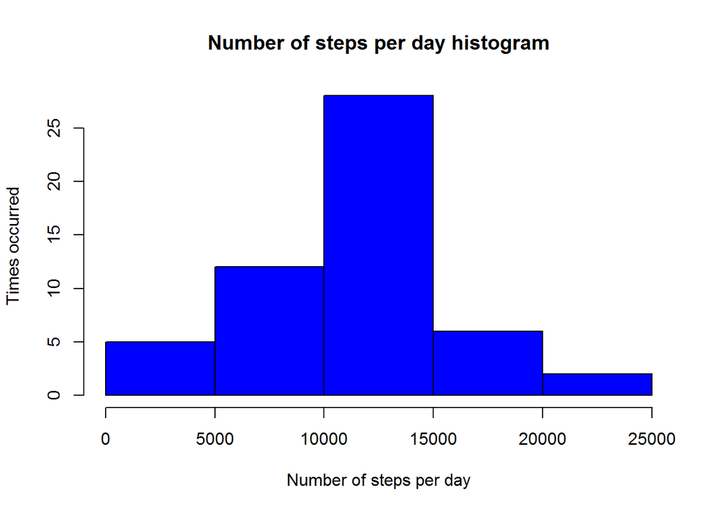

```r
hist(df_summarized$nsteps, col = "blue", xlab = "Number of steps per day"
     , ylab = "Times occurred", main = "Number of steps per day histogram")
```

3. Calculate and report the mean and median of the total number of steps per day

```r
steps_mean = mean(df_summarized$nsteps, na.rm = TRUE)
steps_median = median(df_summarized$nsteps, na.rm = TRUE)
```

The mean is 10766.2 steps per day and the median is  
10765 steps per day.

## What is the average daily activity pattern?

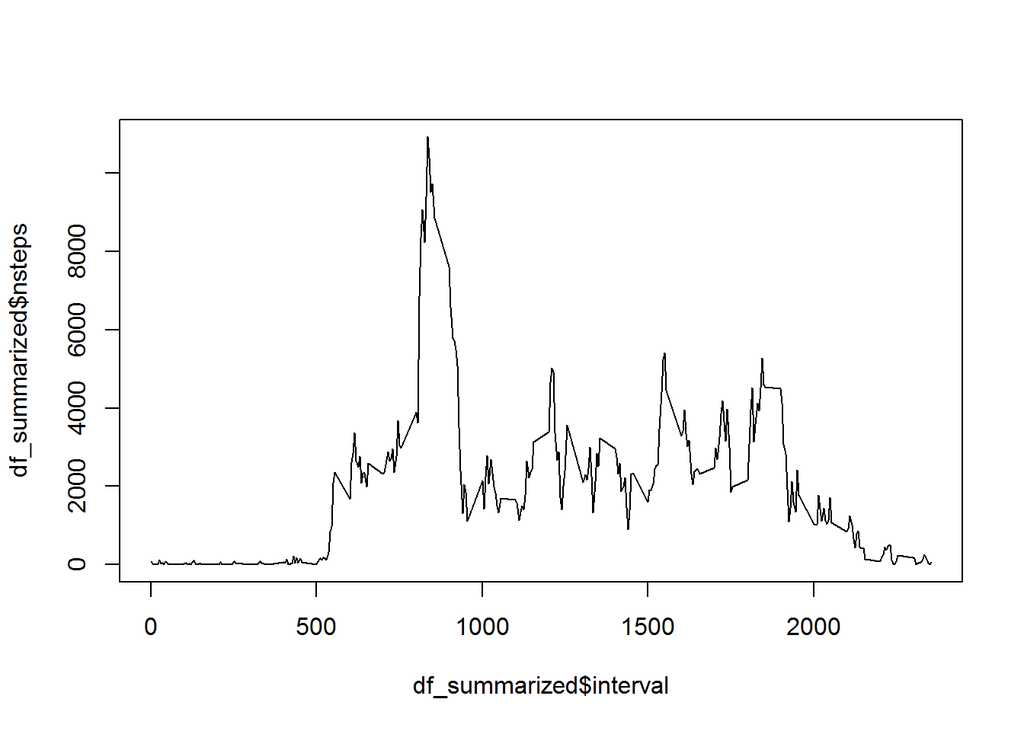

```r
df_2 <- tbl_df(df)
df_grouped <- group_by(df_2,interval)
df_summarized <- summarize(df_grouped, nsteps = sum(steps,na.rm = TRUE))
plot(df_summarized$interval, df_summarized$nsteps, type ='l')
```

2. Which 5 minute interval, on average across all days in the dataset, contains the maximum number of steps?

```r
maximum_interval <- tail(arrange(df_summarized, nsteps),1)[1,"interval"][[1]]
```

The interval that contains the maximum number of steps as average is 835 to 840

## Imputing missing values

1. Calculate and report the number of missing values in the dataset

```r
n_missing_values <- dim(df_2[is.na(df_2$steps),])[1]
```

The number of missing values is 2304.

2. Devise a strategy for filling in all of the missing values in the dataset.

The missing data can be inputted as the average for that interval and that day of the week

3. Create a new dataset that is equal to the original dataset but with the missing data filled in

```r
df_2$weekdays <- weekdays(df_2$date_posix)
df_grouped_weekday_interval <-  group_by(df_2[!is.na(df$steps),]
                                         ,.dots = c("weekdays","interval"))
df_2_summarised <- summarise(df_grouped_weekday_interval
                             , avgsteps = mean(steps))
df_2_null_data <- df_2[is.na(df_2$steps),c("weekdays","interval")]
df_2_null_steps <- merge(df_2_null_data, df_2_summarised
                        , by = c("weekdays","interval"))$avgsteps
df_2[is.na(df_2$steps),"steps"] = df_2_null_steps
```

4. Make a histogram of the total number of steps taken each day and Calculate and report the mean and median total number of steps taken per day. Do these values differ from the estimates from the first part of the assignment? What is the impact of imputing missing data on the estimates of the total daily number of steps?

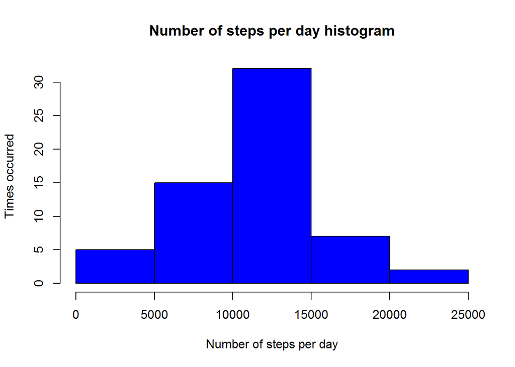

```r
df_grouped <- group_by(df_2,date)
df_summarized <- summarize(df_grouped, nsteps = sum(steps))
hist(df_summarized$nsteps, col = "blue", xlab = "Number of steps per day"
     , ylab = "Times occurred", main = "Number of steps per day histogram")
```

```r
steps_mean_2 = mean(df_summarized$nsteps)
steps_median_2 = median(df_summarized$nsteps)
mean_diff <- steps_mean_2 - steps_mean
median_diff <- steps_median_2 - steps_median
```

After missing values are imputed the mean is 10821.2 steps per day and the median is 11015 steps. This means the mean is increasing by 55.0209226 per day whereas the median is increasing by 250.

## Panel plot

1. Create a new factor variable in the dataset with two levels - “weekday” and “weekend” indicating whether a given date is a weekday or weekend day.

```r
weekdays1 <- c('Saturday','Sunday')
#Use `%in%` and `weekdays` to create a logical vector
#convert to `factor` and specify the `levels/labels`
df_2$weekend <- factor((df_2$weekdays %in% weekdays1),levels=c(FALSE, TRUE)
                       , labels=c('weekday','weekends'))
head(df_2)
```

```
## # A tibble: 6 x 7
##   steps date     interval dt                  date_posix          weekdays
##   <dbl> <fct>       <int> <dttm>              <dttm>              <chr>
## 1     0 2012-10~        0 2012-10-01 00:00:00 2012-10-01 00:00:00 Monday
## 2     0 2012-10~        5 2012-10-01 00:05:00 2012-10-01 00:00:00 Monday
## 3     0 2012-10~       10 2012-10-01 00:10:00 2012-10-01 00:00:00 Monday
## 4     0 2012-10~       15 2012-10-01 00:15:00 2012-10-01 00:00:00 Monday
## 5     0 2012-10~       20 2012-10-01 00:20:00 2012-10-01 00:00:00 Monday
## 6     0 2012-10~       25 2012-10-01 00:25:00 2012-10-01 00:00:00 Monday
## # ... with 1 more variable: weekend <fct>
```

2. Make a panel plot containing a time series plot of the 5-minute interval (x-axis) and the average number of steps taken, averaged across all weekday days or weekend days (y-axis).

[figure not shown]

```r
par(mfrow=c(1,2))

df_grouped <- group_by(df_2[df_2$weekend == "weekday",],interval)
df_summarized <- summarize(df_grouped, nsteps = mean(steps))
plot(df_summarized$interval
     , df_summarized$nsteps, type = 'l' , col = "blue", xlab = "Interval time"
     , ylab = "Average step number"
     , main = "Avg n of steps per weekend day vs interval"
     , cex.main = 0.8)

df_grouped <- group_by(df_2[df_2$weekend == "weekends",],interval)
df_summarized <- summarize(df_grouped, nsteps = mean(steps))
plot(df_summarized$interval
     , df_summarized$nsteps, type = 'l' , col = "blue", xlab = "Interval time"
     , ylab = "Average step number"
     , main = "Avg n of steps per weekday vs interval"
     , cex.main = 0.8)
```